Skip to content

A statistical investigation · 2014 to 2023

# What actually drives gun violence: more people, or less money?

Two explanations get offered for why some states see more gun violence than others: they are simply bigger, or they are poorer. I put both to the test. *Only one of them held.*

**100K+**incidents analyzed

**52**states & territories

**2 sources**merged & modeled

The question

## Population is the easy answer. It is also the wrong one.

Who is actually being harmed, and is it about how many people live somewhere, or how little they have?

It is tempting to assume that bigger states simply have more gun violence, more people, more incidents, end of story. If that were true, the policy conversation would be short and mostly useless: you cannot shrink a state. So I treated it as a hypothesis to be tested rather than a fact to be assumed, and I set it against a second, harder explanation: that gun violence tracks economic hardship, not head count.

To separate the two, I merged ten years of incident level records from the Gun Violence Archive with sixteen years of American Community Survey economic data from the Census Bureau, aligned by year and state. Then I let the data decide which story it supported, using tests that do not assume a tidy bell curve, because gun violence data is anything but tidy.

The data

## Two national datasets, one shared spine: state and year.

The Gun Violence Archive contributed more than one hundred thousand incidents from 2014 to 2023, each carrying date, location, and casualty detail. The Census Bureau's American Community Survey, pulled through the tidycensus interface, contributed poverty rates, median income, and demographic structure for every state across sixteen years. Joined on year and state, the result is a single modeling table of gun violence rates per 100,000 people, each row tagged as higher or lower poverty. The map below is the shape of the problem before any test is run.

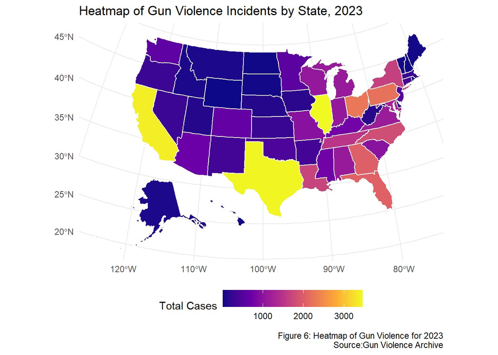

Gun violence incidents by state, 2023. Concentration is uneven, and it does not simply follow the most populous states.

How the claim was tested

## I did not want a correlation I could talk myself into. I wanted a test that could say no.

Permutation tests

### Shuffle, then compare

1,000 relabeling iterations each for population and for poverty, asking whether the real relationship could have arisen by chance. No normality assumed. pop p = 0.259 · poverty p < 0.05

Welch's t-test

### Higher vs lower poverty

A direct comparison of gun violence rates between high poverty and low poverty states, using a test that tolerates unequal variance, which this data badly needed. significant difference

Bootstrap

### How sure, exactly

10,000 resamples to build a confidence interval for the median rate among high poverty states, so the headline number comes with honest bounds, not a single point. 95% CI 11.66 to 14.19

The finding

## Population did not explain it. Poverty did.

When the labels were shuffled a thousand times, population size failed to separate itself from random noise: a permutation p of 0.259 means the apparent link between how many people live in a state and its gun violence rate is the kind of thing you would see by chance roughly a quarter of the time. Poverty was a different story. It cleared significance, survived a Welch's t-test between high and low poverty states, and held up under ten thousand bootstrap resamples.

p = 0.259

Population vs gun violence rate. Not significant. Size is not the driver.

p < 0.05

Poverty vs gun violence rate. Significant across 1,000 permutations.

11.66–14.19

Bootstrap 95% CI, median rate per 100K in high poverty states.

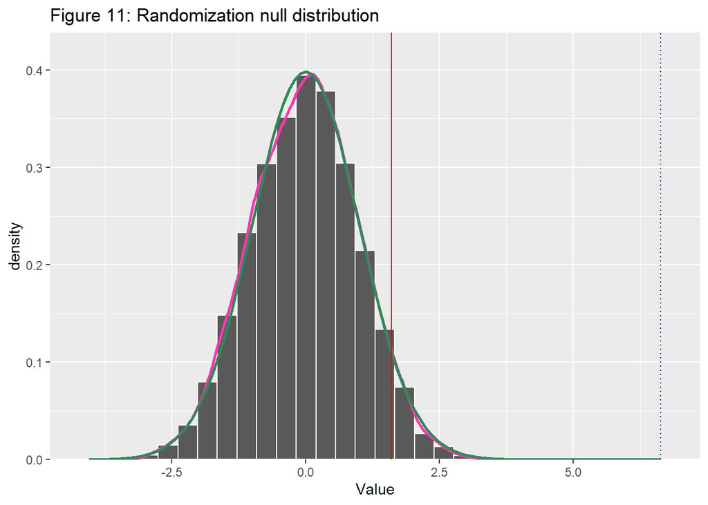

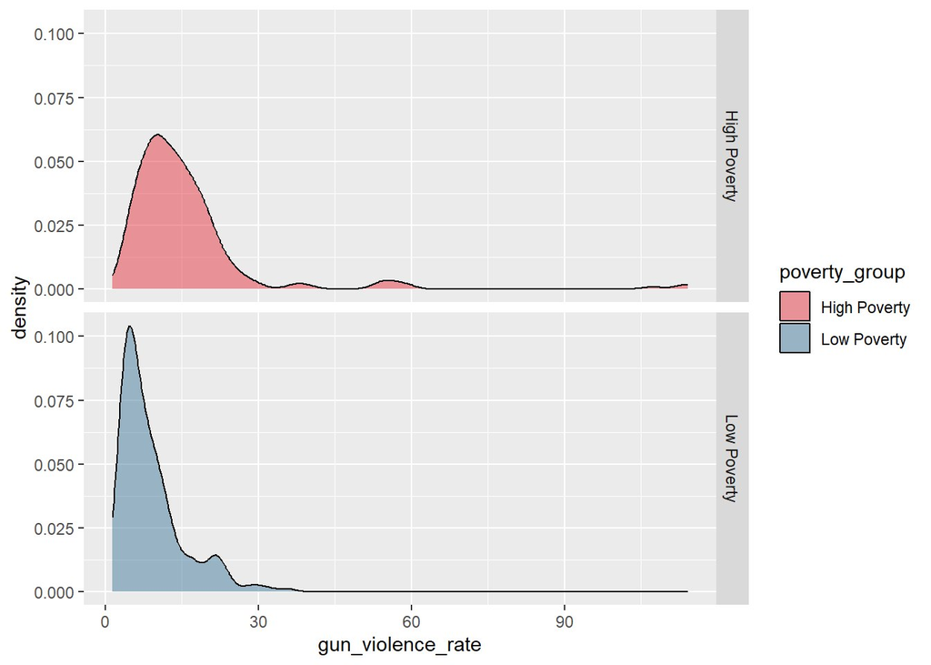

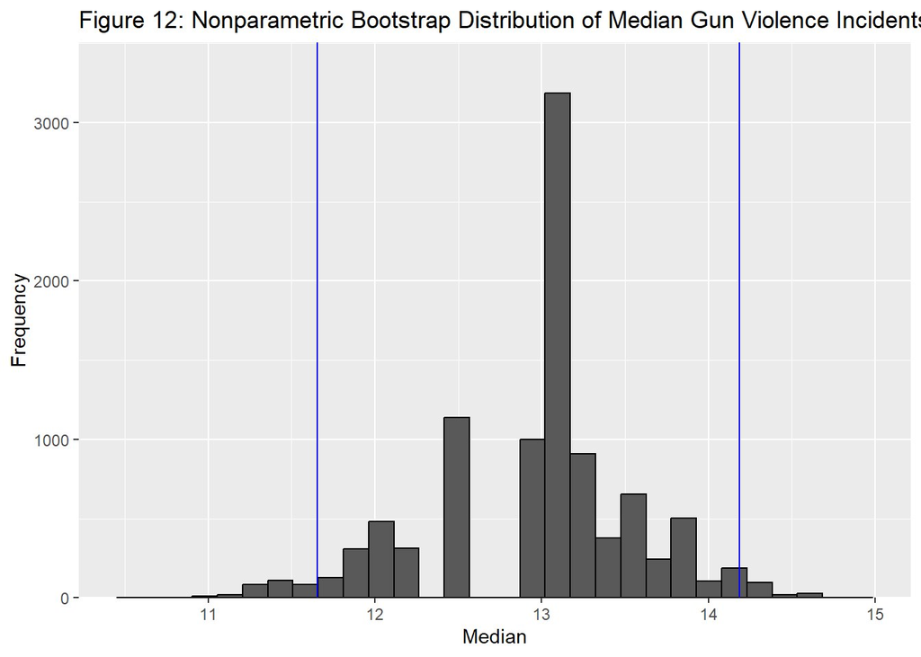

Ten thousand bootstrap resamples of the median gun violence rate in high poverty states. The spread is the honesty: this is the uncertainty behind the headline.

Where and when

## The same data carries texture: a region and a rhythm.

[figure not shown]

Armed robbery incidents by state. Southern states, Texas, Florida, Georgia, sit at the top.

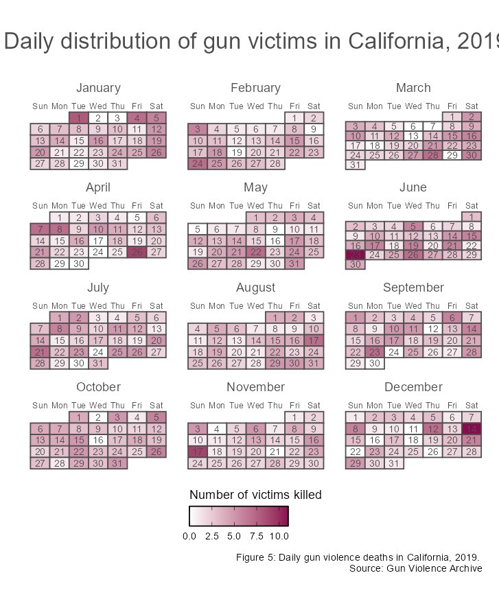

What it means

## A result that points at a lever you can actually pull.

If population were the cause, the problem would be permanent. Poverty is not permanent. That is the whole point.

The reason this distinction matters is not academic. When a driver of gun violence turns out to be population size, there is nothing to do about it. When the driver is economic hardship, the finding stops being a description and becomes an argument: policies that reduce concentrated poverty are, on this evidence, gun violence policy, whether or not they are ever labeled that way.

That conclusion does not rest on my analysis alone, and it should not. It lines up with a substantial body of peer reviewed research. A 2026 study of Maryland found that counties with the highest poverty concentration had significantly higher rates of firearm injury across assault, self harm, and unintentional intents. National work across nearly sixteen thousand neighborhoods ties concentrated disadvantage to gun violence in a reinforcing cycle. The honest caveat, also from the literature, is that the relationship is not perfectly linear everywhere; poverty's effect can soften in counties with low median incomes. My own result carries that same texture, which is reassuring: the variability is real, not a flaw in the measurement.

Corroborating evidence, external to this project: [county-level poverty and firearm injury (Maryland, 2026)](https://www.sciencedirect.com/science/article/pii/S2666535226000170); [concentrated disadvantage across 100 US cities](https://pmc.ncbi.nlm.nih.gov/articles/PMC10728405/); [community-level predictors of gun violence, 2014 to 2017](https://www.sciencedirect.com/science/article/abs/pii/S0277953621003014).

Before any of that

## Every conclusion here sits on data I checked first, not data I trusted.

Merging two national datasets is where quiet errors hide. Before running a single test I audited missingness in both sources, because a poverty rate silently absent for a handful of state years would bias the very comparison the whole project depends on. The plot is not glamorous. It is the reason the rest of the numbers are trustworthy.

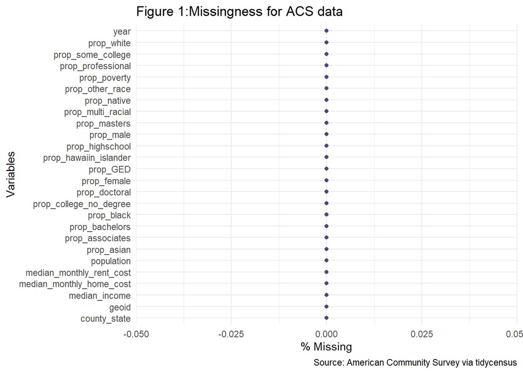

In one line

Gun violence in America tracks how little people have, not how many of them there are.

That reframes it from an unsolvable fact of geography into a consequence of policy, which means it can be changed.

[Read the full interactive report](https://cece15.github.io/Gun-Violence-Poverty-Analysis/report.html) [View the code](https://github.com/cece15/Gun-Violence-Poverty-Analysis)

cmutuaa@gmail.com [LinkedIn](https://www.linkedin.com/in/cynthia-mutua/) [GitHub](https://github.com/cece15)

R Quarto tidyverse tidycensus permutation & bootstrap